# Enquête précarité à l’OFB

Analyse des résultats

CGT Environnement

27/01/2026

[figure not shown]

# 1 RÉSUMÉ

Avec un taux de réponse 62%, cette enquête est un succès.

A l’OFB, de nombreuses missions permanentes sont confiées à des agents précaires. L’incertitude professionnelle impacte fortement la qualité de vie de ces collègues, tant au plan professionnel que personnel.

Les femmes représentent les deux tiers des précaires à l’OFB. Parmi elles, les catégorie C (n = 21) ont un revenu mensuel net médian de 960€. Toutes catégories confondues, les répondant.es déplorent des revenus insuffisants et inférieurs à ceux des permanents.

Ces personnels, fréquemment déjà expérimentés à leur arrivée à l’OFB, sont dans l’ensemble très diplômés, en grande partie catégorie A et affectés à la DG sur des missions techniques. Leur âge s’échelonne entre 20 et 65 ans et la durée de contrat la plus fréquente est 3 ans.

Les impacts de la précarité professionnelle sont très concrets sur les conditions de logement, les trajets domicile - travail ou la vie familiale. Plus de la moitié des répondant.es déclare même que cette précarité altère leur santé.

Retards dans la signature du contrat et dans le versement des premiers salaires, manque d’information et d’accès à la formation … de nombreux dysfonctionnements de la fonction RH sont relevés, qui ajoutent de l’incertitude à l’incertitude. Malgré l’engagement des collègues en charge de la RH, eux-mêmes souvent en souffrance, les moyens alloués sont notoirement insuffisants.

Malgré les griefs énoncés ci-dessous, la grande majorité des sondé.es aspire à poursuivre sa carrière à l’OFB. De nombreux *verbatim* expriment les bons côtés du travail dans l’établissement - missions stimulantes et motivantes, soutien de la part des collègues, utilité. On observe ainsi un tiraillement entre l’attachement aux missions et les difficultés découlant de la précarité.

# 2 L’enquête

## 2.1 Définition

La précarité désigne ici la “*situation sociale d’une personne dont les conditions de vie (revenus, logement, situation familiale…) et d’emploi à venir sont marquées par une forte incertitude*” ([Alternatives économiques](https://www.alternatives-economiques.fr/dictionnaire/definition/97697)).

## 2.2 Objectifs et contexte

En 2022, 20% des agents publics sont des contractuels. L’OFB ne fait pas exception. Depuis sa création, le recours aux emplois précaires est massif. Selon le dernier Rapport Social Unique (RSU) disponible, l’effectif cumulé des personnels précaires à l’OFB était de 551 en 2023, soit 20% des 2750 ETP “sous plafond”.

Le marché actuel de l’emploi est si bouché qu’un poste, même temporaire, à l’OFB, peut apparaître comme une opportunité. Il n’en reste pas moins que l’incertitude du lendemain est reconnue comme un facteur de stress et de dégradation des conditions de vie.

Parmi les postes temporaires à l’OFB, de nombreux “contrats de projets” correspondent à des missions pérennes et régaliennes ainsi maquillées pour capter des financements européens. D’autres sont proposés en CDD de 3 ans, moins rémunérés que les titulaires, renouvelables une fois et éventuellement “CDIsables” à terme. Cette période d’essai de six ans contraint à repostuler sur son propre poste à mi-parcours, avec la crainte de se voir préférer un titulaire de la Fonction Publique.

Concernant le statut de Volontaire de Service Civique, les textes indiquent que “ces missions ont pour point commun de ne pas pouvoir se substituer à l’activité d’un salarié”. Or, dans la réalité, nombre de missions permanentes de l’établissement sont exécutées par des VSC. Les mêmes considérations valent pour les alternant.es, voire pour les intérimaires.

La CGT Environnement revendique l’emploi de fonctionnaires sur l’ensemble des missions pérennes de l’établissement et, à travail égal, un salaire égal.

**La CGT Environnement a ainsi lancé une enquête pour objectiver les conditions d’emploi et les conséquences de la précarité sur le vécu des personnels non permanents de l’OFB, et ce afin de mieux défendre leurs droits et leurs intérêts.**

Elle s’adressait à tous les personnels de l’OFB en CDD, intérim, alternance ou VSC.

## 2.3 Dynamique de réponse

L’enquête a été lancée le 25 novembre 2025 et clôturée le 17 décembre 2025. Elle a permis de recueillir **341 réponses**. En rapportant à l’effectif de 551 travailleurs précaires (RSU 2023), on peut estimer que le **taux de réponse est de l’ordre de 62%**, ce qui est considérable. Il assure la fiabilité des enseignements de l’enquête. Il révèle aussi un besoin d’expression des personnels précaires qui, souhaitons-le, sera entendu par la direction de l’OFB et les tutelles.

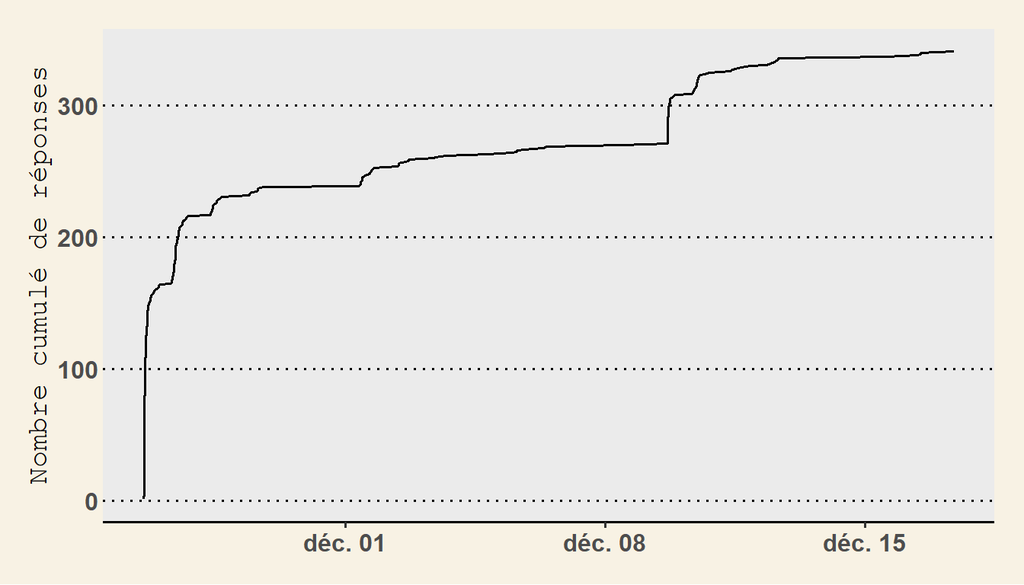

Figure 1: Cumul du nombre de réponses enregistrées au fil du temps.

Dans les résultats qui suivent, nous n’avons pas cherché à commenter systématiquement les données de chaque graphique, en particulier quand leur interprétation était évidente, dans un but de simplicité et de parcimonie.

# 3 Votre poste actuel

## 3.1 Profil des répondant.es

> *Quel est votre contrat actuellement ?*

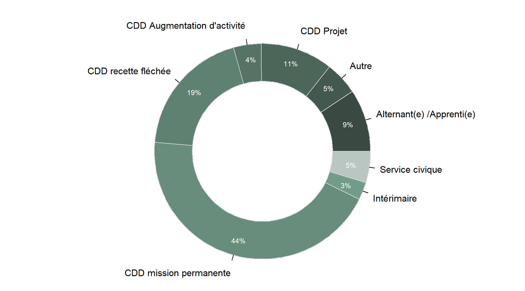

Figure 2: Répartition des réponses par type de contrat.

Le statut le plus fréquent est de loin le CDD dont les différentes modalités cumulent 78% des répondant.es. La part des CDD sur des missions permanentes est importante, avec 44% du total.

> *Quelle est la durée de votre contrat ?*

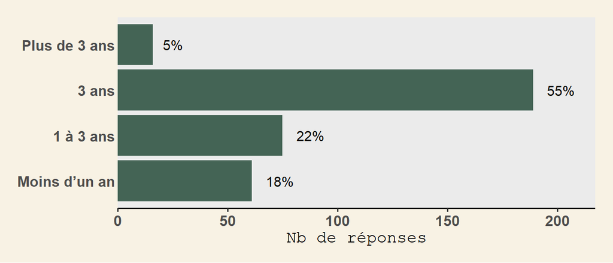

Figure 3: Répartition des réponses par durée de contrat.

> *Quelle est votre fonction ?*

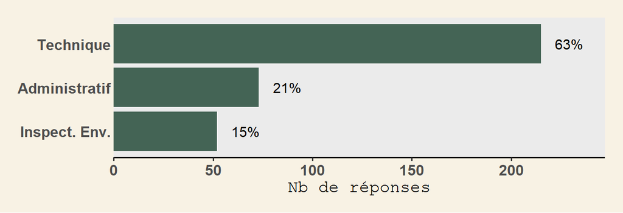

Figure 4: Répartition des réponses par type de poste.

> *Quel est le rattachement de votre poste ?*

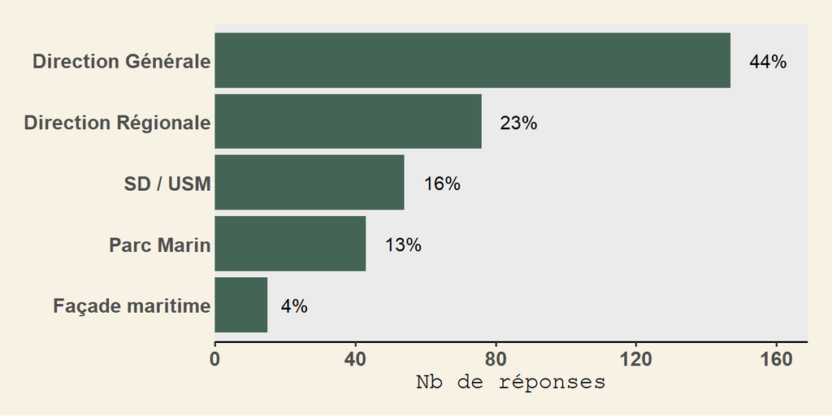

Figure 5: Répartition des réponses par rattachement du poste.

> *Quelle est la catégorie de votre poste ?*

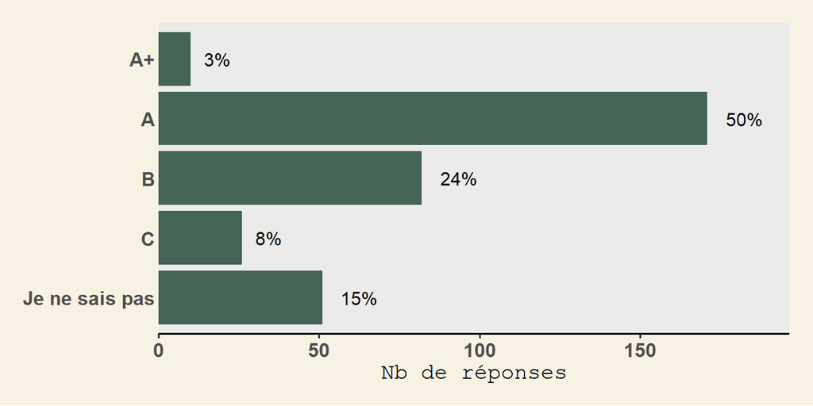

Figure 6: Répartition des réponses par catégorie.

Les graphiques clarifient ce que sont, le plus souvent, les postes pourvus par des personnes précaires. Les missions sont essentiellement techniques, de catégorie A, et les affectations le plus souvent à la Direction Générale en CDD de durée 3 ans.

## 3.2 Adéquation au poste

> *Pensez-vous que votre poste est en adéquation avec votre niveau de formation et votre ancienneté ?*

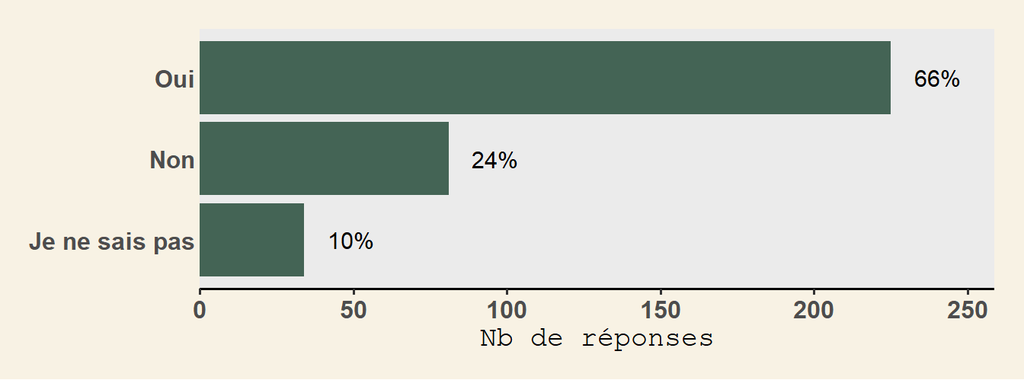

Figure 7: Adéquation entre, d’un côté, le poste et, de l’autre, le niveau de formation et l’ancienneté.

Si la majorité des répondant.es estime son poste en adéquation avec sa formation et son ancienneté, avec 24% de réponses négatives, un quart des sondés estiment que ce n’est pas le cas.

> *Verbatims de complément*

La question ci-dessus était complétée d’une question ouverte qui a recueilli 68 expressions libres (20%). Parmi les thématiques abordées, on trouve :

**- Une rémunération qui n’est pas en adéquation avec le niveau de formation** (10 commentaires)

- “*J’ai un Bac +5, je suis au smic avec 1 an de CDD et un service civique au sein de l’OFB*”
- “*Les responsabilités liées au poste oui, la rémunération et la valorisation absolument pas.*”
- “*Les CDD se retrouvent avec une prise en charge similaire aux homologues fonctionnaires, mais sans bénéficier de leurs primes, donc avec un pouvoir d’achat moindre.*”
- “*Bac + 5 obtenu, rémunération faible, inégalité avec les titulaires du concours qui gagnent environ 400€ net de plus pour le même métier.*”

**- Une reprise d’ancienneté lors de la signature du contrat largement insuffisante** (14 réponses)

- “*Scandaleux et injuste de ne pas reprendre notre expérience du privé entièrement alors qu’elle sert au quotidien dans notre travail au sein de l’OFB.*”
- “*Lorsque j’ai postulé à un CDD de 3 ans à l’OFB et ai été prise, ils n’ont repris que les 2/3 des 1,5 ans que j’ai passé à travailler pour l’OFB…*”
- “*Ma vrai ancienneté (+20 ans) n’a pas été prise en compte. Dans le cas de CDD, l’OFB insiste à plafonner l’ancienneté à 8 ans et ne fait même pas évoluer ce chiffre en tenant compte de l’ancienneté additionnelle acquise via des contrats précédents à l’OFB même.*”
- “*Prise en compte quasi-nulle de l’expérience, du diplôme et du niveau d’expertise !*”
- “*17ans expérience sur poste équivalent et moins de 100euros d’écart avec un néophyte… je pars dans 3semaine pour un poste d’ingénieur territorial où il placent les contractuels sur une grille équivalente aux titulaires*”
- “*J’ai 11 ans d’expérience dans le privé et à l’international, c’est ce qui a plu dans mon profil par contre quasiment rien n’a été retenu dans ma reconstitution de carrière (échelon 4 de catégorie A retenu soit 2 ans d’ancienneté) - mon salaire est à la limite de la dignité.*”
- “*J’ai déjà travaillé plus de 13 ans dans le public et une dizaine d’années dans le privé. Le contrat à l’OFB nous impose un choix entre les expériences dans le privé et les expériences dans le public. Néanmoins, le plafond des années comptant pour l’ancienneté est de 11 ans.*”

**- Une inadéquation du niveau du poste avec les missions demandées** (10 réponses)

- “*(Agent de catégorie C) J’ai un master, je réalise des missions qui correspondent à des missions d’agents en catégorie B voire A…*”
- “*Mes compétences sont sous utilisées*”
- “*Poste pour un junior mais beaucoup d’exigence au recrutement*”
- “*Poste technique et administratif avec des missions de fond (intéressantes et valorisantes mais) qui dépassent les missions du contrat*”

L’insuffisance des rémunérations est un élément fort de cette enquête (cf. analyse des verbatim ci-dessous). Les répondant.es déplorent en particulier une mauvaise prise en compte de l’ancienneté préalable à l’arrivée à l’OFB et du niveau de formation.

En outre, les répondant.es déplorent l’immense décalage entre, d’un côté, les compétences mobilisées et l’engagement demandé et, de l’autre, le niveau de reconnaissance (dont la rémunération) et de sécurité de l’emploi des personnels précaires.

# 4 Votre parcours

## 4.1 Avant l’OFB

> *Votre/vos expériences précédentes étaient dans :*

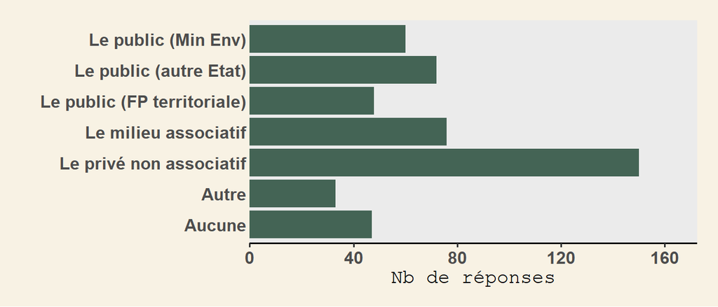

Figure 8: Expériences professionnelles antérieures à l’OFB (plusieurs réponses possibles).

## 4.2 A l’OFB

> *En quelle année êtes-vous arrivé.e dans l’établissement ?*

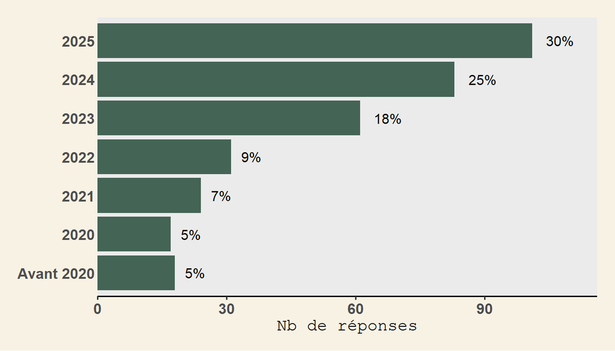

Figure 9: Répartition des réponses par année d’arrivée à l’OFB.

> *Avez-vous dû venir travailler à l’OFB sans avoir votre nouveau contrat “en main” ?*

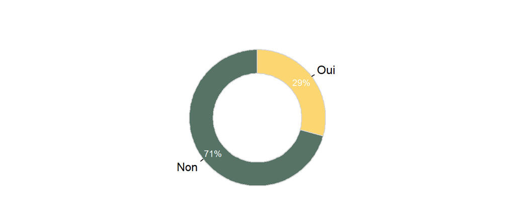

Figure 10: Répartition des réponses selon que l’embauche s’est faite contrat en main (Oui) ou non.

Près de 1/3 des agents précaires ont embauché sans même disposer de leur contrat de travail signé ! En d’autres termes sans en connaître précisément les conditions. Difficile, dès lors, de négocier la reprise de son ancienneté et, surtout, impossible de vérifier que la DRH n’a rien omis. Le manque de moyens alloués au fonctionnement de la DRH a des conséquences bien concrètes pour la vie des agents.

A titre de comparaison, pour un CDD dans le privé, la loi prévoit que « *le contrat de travail est transmis au salarié, au plus tard, dans les deux jours ouvrables suivant l’embauche.* » (Code du travail, Article L1242-13) ; le non-respect de ce délai de transmission n’entraîne pas, à lui seul, la requalification du CDD en CDI mais, en l’absence de respect de cette disposition, le salarié a droit à une indemnité, à la charge de l’employeur, égale au maximum à un mois de salaire ([source](https://www.service-public.gouv.fr/particuliers/vosdroits/F36)).

## 4.3 Successions de contrats à l’OFB

> *Est-ce votre premier contrat à l’OFB ?*

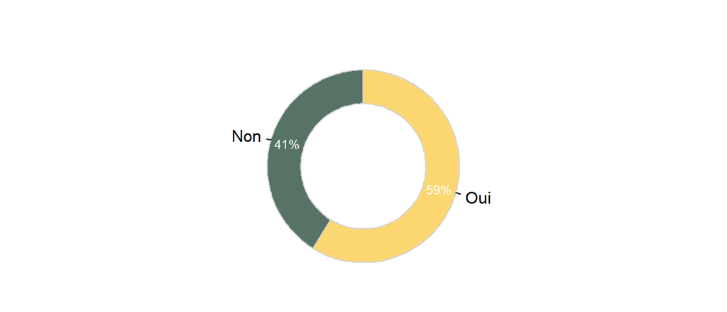

Figure 11: Répartition des réponses selon que c’est un premier contrat à l’OFB (Oui) ou non.

**NOTE : Les trois questions qui suivent ne concernent que les répondants qui en sont minimum à leur second contrat à l’OFB.**

> *Combien de contrats avez-vous eu en comptant l’actuel ?*

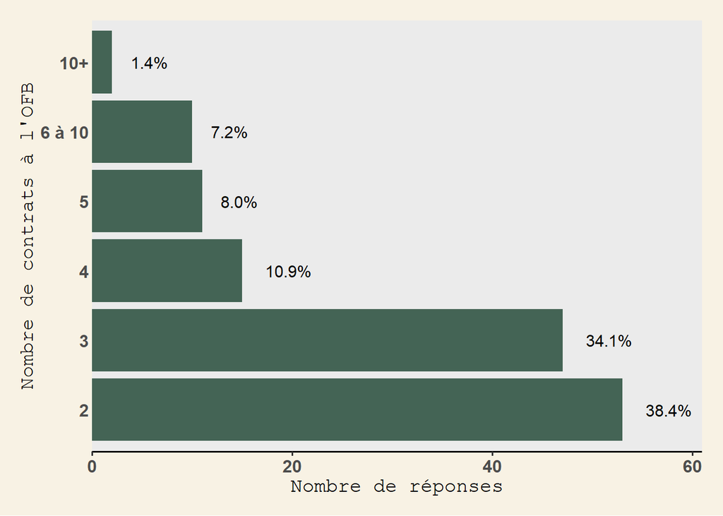

Figure 12: Répartition des réponses selon le nombre de contrats successifs à l’OFB.

> *S’agissait-il du même poste ?*

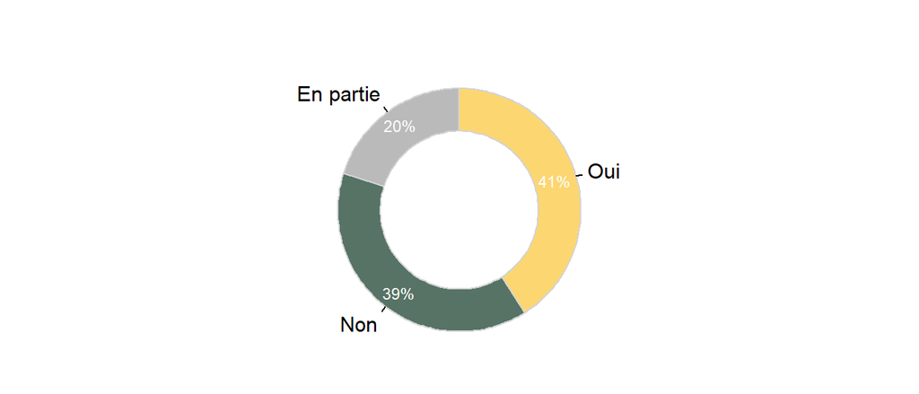

Figure 13: Répartition des réponses selon que c’est la reconduction sur un même poste (Oui) ou non.

La majorité des renouvellements de contrat se produit sur des postes absolument ou partiellement identiques.

> *En quelle année avez-vous pris votre poste actuel ?*

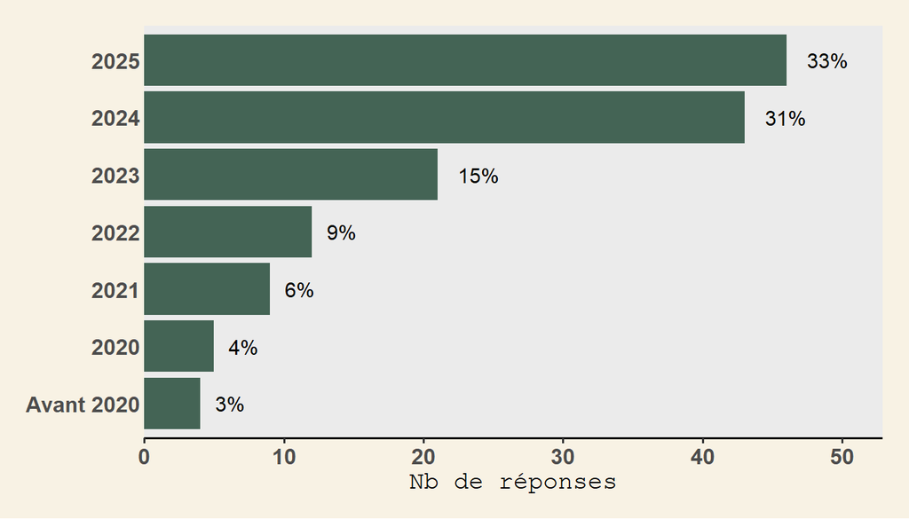

Figure 14: Répartition des réponses selon l’année de prise du poste actuel.

Pour de nombreux collègues, les contrats à l’OFB s’enchaînent. Ils sont 23 à déclarer en être à leur 5ème contrat ou plus, avec un record à 23. Ces collègues sont donc dans une situation paradoxale de précarité durable, avec une insécurité professionnelle permanente. De telles situations sont moralement indignes d’un employeur public. Leur légalité est même questionnable car il s’agit dans de nombreux cas de missions permanentes. La cause en est connue : le refus de recruter des fonctionnaires par concours (ou *a minima* en CDI), afin de disposer d’un vivier de salariés jetables et bon marché servant de variable d’ajustement à la politique austéritaire.

# 5 Votre rémunération

> *En comparaison avec votre poste précédent, votre revenu est :*

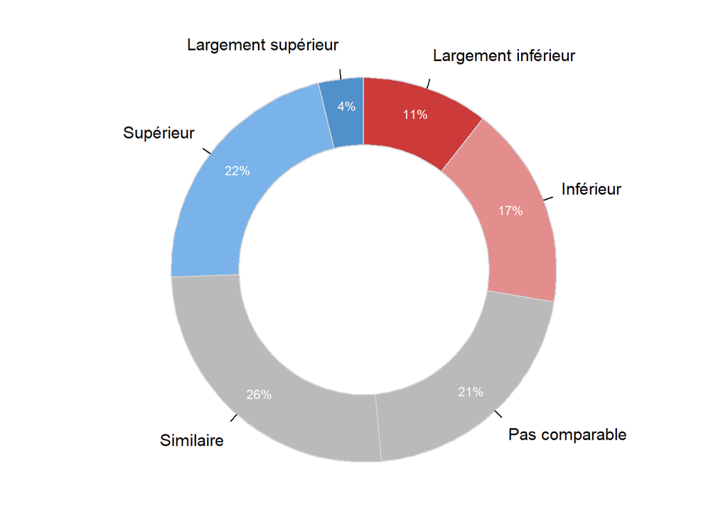

Figure 15: Différence de rémunération entre le poste actuel et le précédent.

> *Voulez-vous en préciser le montant net mensuel ?*

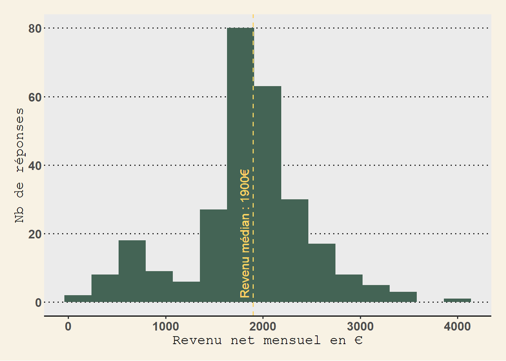

Figure 16: Distribution des revenus mensuels nets en euros.

Si l’on décline le revenu médian par genre et catégorie :

| Revenu net médian en € | A | B | C |
| --- | --- | --- | --- |
| Femme | 2 000 | 1 800 | 960 |
| Homme | 2 100 | 1 800 | 1 440 |

> NB dans le tableau ci-dessus ne figurent que les catégories A, B et C s’étant déclaré.es femme ou homme car les autres réponses comptaient des effectifs trop faibles.

Le revenu médian déclaré est de 1900€ nets par mois. Les écarts entre catégories A et B et, au sein de ces catégories, entre femmes et hommes, sont faibles. En revanche, on note un très fort décrochage pour les catégorie C, en particulier chez les femmes dont le salaire médian est de seulement 960€. Il s’agit probablement de temps partiel dont il serait intéressant de savoir s’il est choisi ou contraint. Un niveau de rémunération très loin de permettre une vie décente si la situation familiale n’apporte pas de soutien.

> *Votre revenu a-t-il augmenté depuis votre arrivée en poste ?*

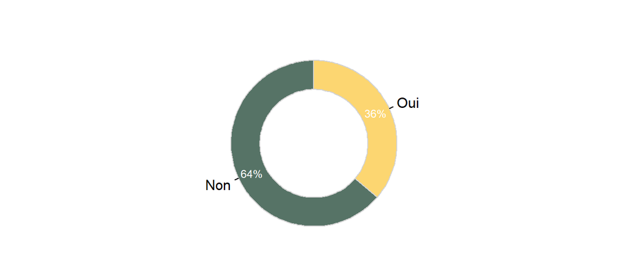

Figure 17: Répartition des réponses selon que le revenu a augmenté depuis la prise de poste (Oui) ou non.

> *Pensez-vous que votre rémunération est en adéquation avec votre niveau de formation et votre ancienneté ?*

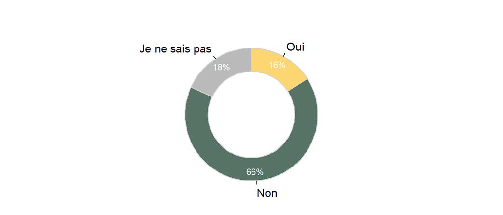

Figure 18: Répartition des réponses selon que la rémunération est jugée adéquate (Oui) ou non.

Sur les 140 réponses signalant au moins un deuxième contrat avec l’OFB, 72 signalent une augmentation de rémunération alors que 67 (47 %) déclarent une absence d’augmentation. Les textes encadrant l’emploi de contractuels en CDD prévoient une prise en compte de l’ancienneté et de l’expérience acquise lors des différents contrats. L’établissement devrait donc prendre en compte la réglementation et permettre une réelle évolution salariale entre deux contrats. Dans le cadre des contrats sur recettes fléchées, contrat de projet, il est impératif que la convention prévoie ce type d’augmentation de salaire. Ces remarques étant faites, il est très probable que les collègues à contrat successifs n’aient pas, pour beaucoup, de contrat à en-tête OFB, avec des employeurs « relais » (organismes de recherche ou techniques tiers) permettant à l’établissement de contourner ses contraintes en termes de plafond d’emploi. Ces combines permettent plus aisément de ne pas accorder d’augmentation d’un contrat au suivant…

# 6 Votre prise de poste

> *Vous avez été bien informé.e sur :*

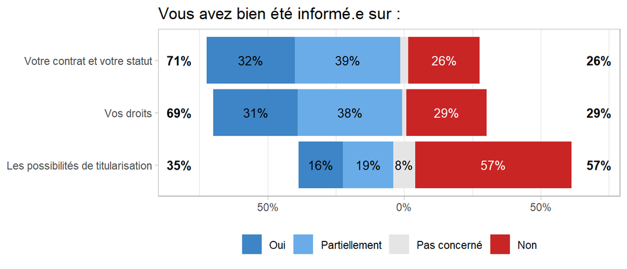

Figure 19: Répartition des réponses sur le niveau d’information.

Le graphique ci-dessus et le corpus révèlent un déficit structurel d’information et d’accompagnement RH à l’OFB des personnes en situation précaire. Ce déficit touche l’ensemble des aspects du contrat : embauche, rémunération, avancement, renouvellement, droits et titularisation. Il faut souvent se débrouiller pour trouver les informations, les réponses en matière de RH étant généralement tardives, incomplètes voire contradictoires. La lisibilité des contrats (notamment contrats de projet) est jugée insuffisante, générant incertitudes et erreurs. L’accès aux concours et parcours de titularisation est mal expliqué. Les règles de rémunération et d’avancement sont jugées opaques et la communication autour de la complémentaire santé/prévoyance déficiente. Les droits syndicaux sont peu connus. Les répondant.e.s s’appuient principalement sur leurs collègues comme source d’information.

Il est impératif que l’établissement réalise une campagne d’information sur les droits des personnels, notamment pour les emplois précaires, et plus particulièrement sur les possibilités de titularisation.

Une question ouverte permettait d’apporter des précisions sur le niveau d’information.

> *Quelques verbatim d’illustration :*
- “*Aucune information avant la prise de poste sur les barèmes appliqués, même après l’avoir demandé plusieurs fois. Aucune information de la part des RH à l’arrivée sur le poste sur les conditions de renouvellement au bout de 3 ans ni sur les conditions de réévaluation du salaire sur la durée du contrat (décision DGDR-DRH 2022-28 sur les contrats de projets très peu claire, celle d’avant encore moins). Résultat : signature d’un contrat sans avoir tous les éléments en main pour prendre une décision éclairée, et incertitude pendant les 3 ans du contrat sur les conditions de renouvellement.*”
- “*Je cherchais depuis mon arrivée comment être titularisée, peu de réponses cohérentes pour m’accompagner, au final j’ai abandonné.*”
- “*Aucune réelle information avant la prise de poste ainsi que lors de mon arrivée. Il a fallu se renseigner par soi-même sur l’intranet et à la lecture du contrat. Un guide d’accueil semble essentiel.*”

> *Avez-vous connu des difficultés au moment de votre prise de poste, notamment en lien avec votre statut de contractuel ?*

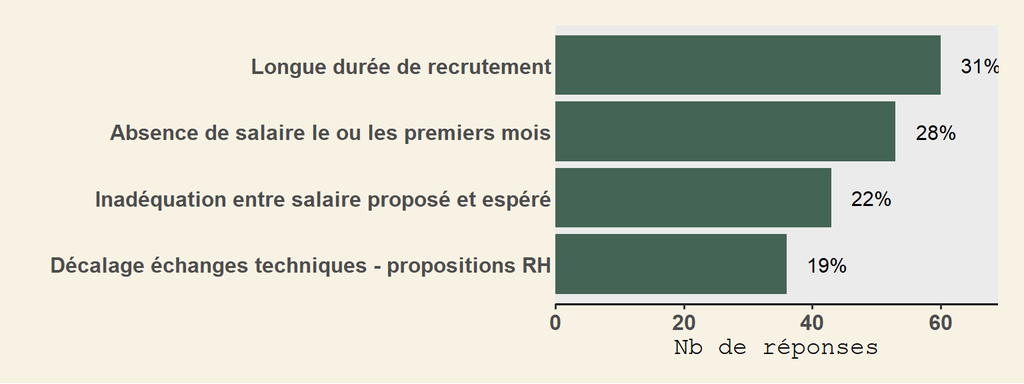

Figure 20: Répartition des réponses selon les principales difficultés rencontrées lors de la prise du poste.

Près du tiers des réponses pointent la longueur des recrutements. Or s’agissant de personnes en situation de précarité, cette attente est source de stress et de maintien dans des conditions de faibles ressources.

Encore plus scandaleux et totalement illégal : 28 % des réponses indiquent une absence de salaire le ou les premiers mois ! Est-il utile de revenir sur les conséquences très sévères d’une telle défaillance sur la vie quotidienne des agents ? La population concernée, ayant structurellement des ressources faibles, l’absence de salaire a évidemment des répercussions graves sur la vie quotidienne, les relations avec le propriétaire de sa résidence, sa banque, les achats indispensables, les loisirs…

> *Verbatims complémentaires*

Ci-dessous une sélection de réponses à la question ouverte associée pour mieux appréhender le stress causé par l’incertitude lors du recrutement. Une part importante de ce stress, par exemple celle conséquence de l’incertitude, serait pourtant évitable.

-**Des situations de réelle difficulté financière et de logement.**

- « *J’ai 2 enfants, un Bac+8, 2100 euro net par mois et je donne 500 euros par mois pour aller bosser sur Paris. Après la nounou, les courses et les frais de la maison, on ne peut pas manger moi et ma femme à notre faim pour que les enfants puisse eux avoir des repas équilibrés.* »
- « *Recherche de logement très compliquée.* »
- « *On nous demande de démissionner pour pouvoir faire des prises de postes rapides OFB, mais aucune garantie en face…* »
- « *J’ai signé mon contrat 18 jours après ma prise de poste.* »
- « *Absence de paie durant 2 mois lors de mon renouvellement.* »

-**Accompagnement RH défaillant** : réponses tardives, incohérentes, voire inexistantes.

- « *Pour avoir la DRH c’est pas facile… relances infructueuses.* »
- « *Aucune réponse des services RH sauf pour m’obliger à démissionner.* »

-**Niveau de rémunération** : Reprise d’expérience opaque et inéquitable, absence de négociation.

- « *Première proposition de salaire inférieure au SMIC.* »
- « *Reprise d’expérience refusée sans aucun fondement légal.* »
- « *La dérogation pour négociation m’a été refusée “au regard de mon CV”.* »

-**Erreurs et fluctuations de paie** (acompte, trop-perçu, temps partiel, absence de fiche).

- « *Pas de fiche de paie le premier mois : compliqué pour la CAF.* »
- « *Acomptes pendant 3 mois, pas de bulletin.* »

-**Absence ou faiblesse de l’accompagnement** à l’arrivée : cadrage des missions et formations insuffisants.

- « *Pas d’accompagnement de ma hiérarchie sur la prise de poste.* »
- « *Jeté dans le grand bain, débrouille-toi avec les collègues.* »
- « *Formation dispensée 6 mois après la prise de poste.* »

# 7 Les conséquences de la précarité

> *Avez-vous dû déménager pour prendre votre poste ?*

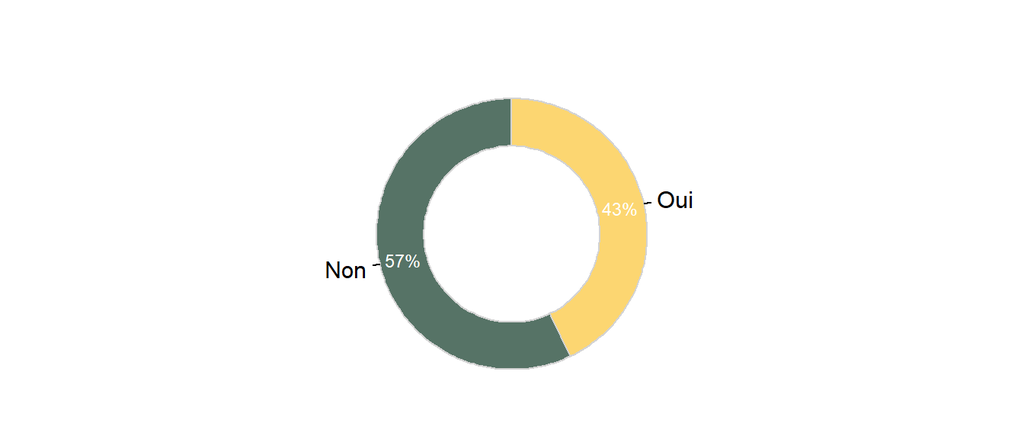

Figure 21: Répartition des réponses selon que la prise du poste a nécessité un déménagement (Oui) ou non.

> *La précarité impacte :*

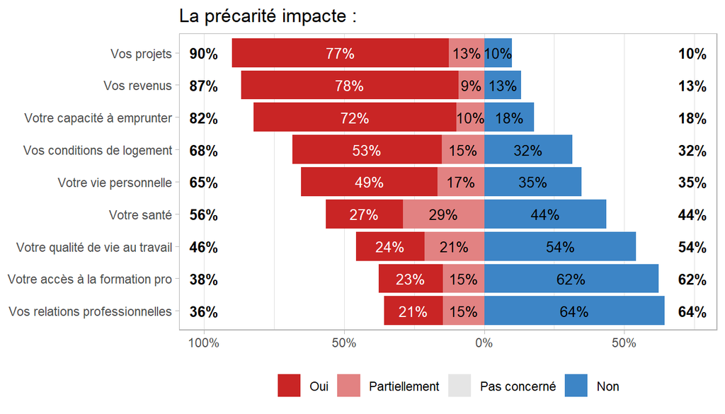

Figure 22: Répartition des réponses selon les impacts sur différents aspects de la vie professionnelle et personnelle.

L’impact de la précarité déclaré par les répondants est massif sur leur capacité à se projeter (90%) et sur leur niveau de vie (87%), ce qui recoupe largement l’analyse des *verbatims*. Ces revenus faibles - inférieurs à ceux des titulaires effectuant le même travail - et non pérennes compromettent la possibilité de se loger décemment et d’emprunter auprès d’une banque.

La qualité de vie au travail est considérée comme dégradée par presque la moitié des répondant.es, qui sont encore plus du tiers à se déclarer pénalisés en termes d’accès à la formation et de relations professionnelles.

> *Du fait de votre condition d’emploi, rencontrez-vous d’autres difficultés ?*

Les réponses à cette question ouverte recoupent principalement trois thématiques :

**- Une précarité sur le logement**

L’accès au logement apparaît comme l’une des conséquences les plus concrètes et pénalisantes du statut précaire. Les refus liés à l’absence de CDI entraînent des situations de précarité résidentielle.

- « *Il m’a fallu plus d’un an pour trouver une location* »
- « *Les propriétaires refusent les profils en CDD* »
- « *Double loyer par obligation* »

**- Une insécurité professionnelle et une impossibilité de se projeter**

Les agents en CDD expriment très majoritairement un sentiment d’instabilité durable, parfois après plusieurs années d’ancienneté. L’incertitude sur le renouvellement des contrats et l’absence de garanties claires empêchent toute projection professionnelle et personnelle.

- « *Vivre dans une incertitude professionnelle après 9 ans d’ancienneté* »
- « *Stress constant sur la pérennité de mes contrats* »
- « *Impossible de faire des projets à long terme* »

**- Précarité financière et inégalités de traitement**

Le troisième thème central concerne des rémunérations jugées insuffisantes, sans évolution possible pendant la durée des contrats, et des différences de traitement comparé aux agents titulaires, à missions équivalentes.

- « *Salaire inférieur aux titulaires sur le même type de poste* »
- « *Pas d’augmentation possible sur les 3 ans de contrat* »
- « *Arrêt maladie = perte financière importante* »

Logement, niveau de vie, Qualité de Vie au Travail, capacité à se projeter : les conséquences de la précarité sur le quotidien, que l’on pressentait avant l’enquête, sont donc largement confirmées. Leur gravité ressort clairement des *verbatim*.

Depuis sa création, l’OFB est loin d’être un employeur modèle. L’établissement, sous couvert de mesures générales s’appliquant dans la fonction publique, pratique le moins-disant social en s’alignant systématiquement sur les mesures les plus défavorables aux personnels. Les non-permanents sont particulièrement exposés à ces pratiques, en particulier au plan RH.

# 8 Qui a répondu ?

## 8.1 Genre

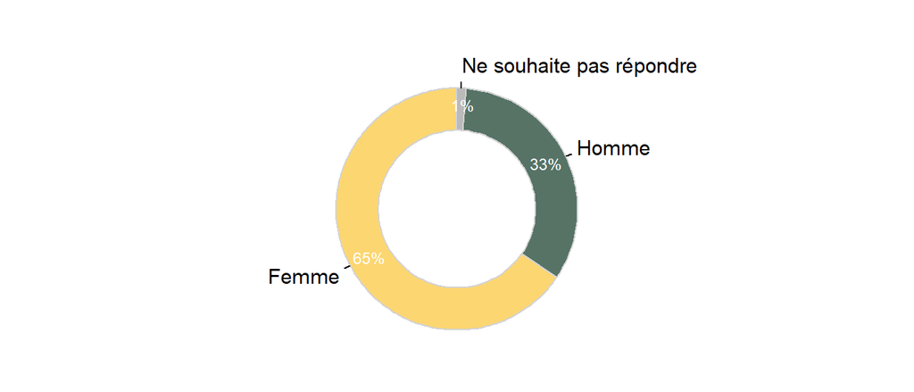

Figure 23: Répartition des réponses par genre.

## 8.2 Age

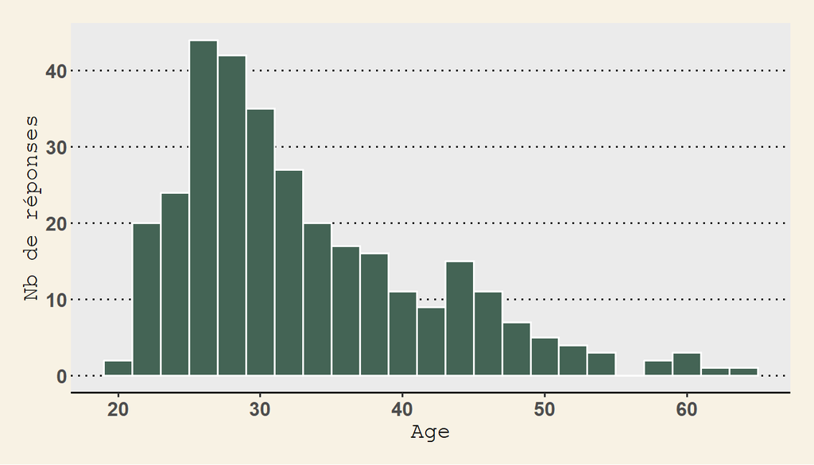

Figure 24: Distribution des âges des répondant.es.

## 8.3 Diplôme le plus élevé

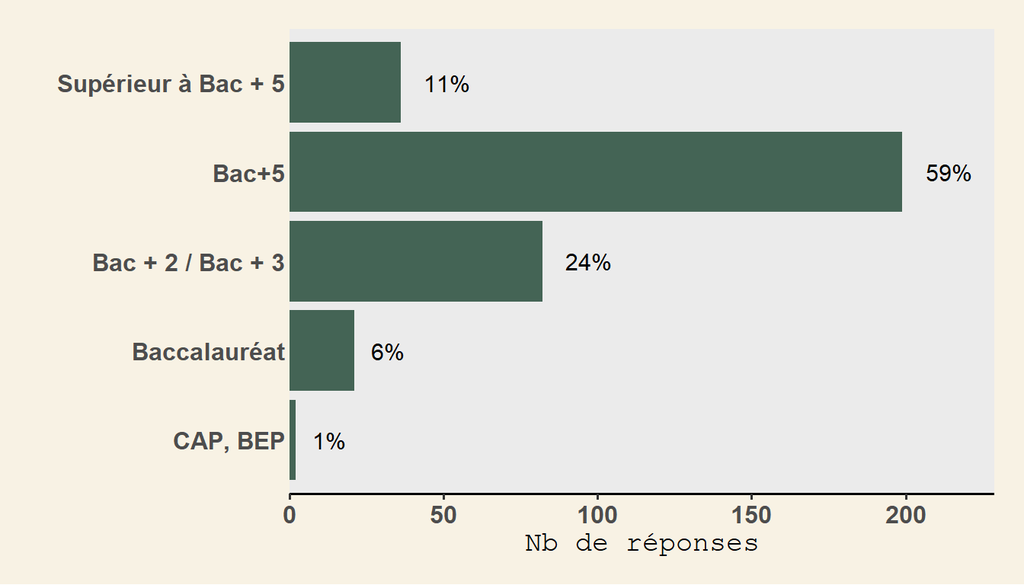

Figure 25: Répartition des réponses selon le niveau de diplôme.

## 8.4 Année d’obtention de ce diplôme

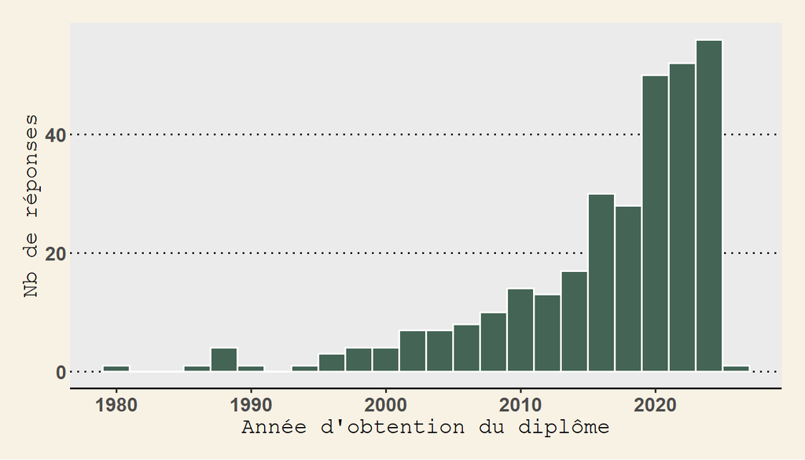

Figure 26: Répartition des réponses selon l’année d’obtention du diplôme.

## 8.5 Nombre d’années d’expérience professionnelle avant l’OFB

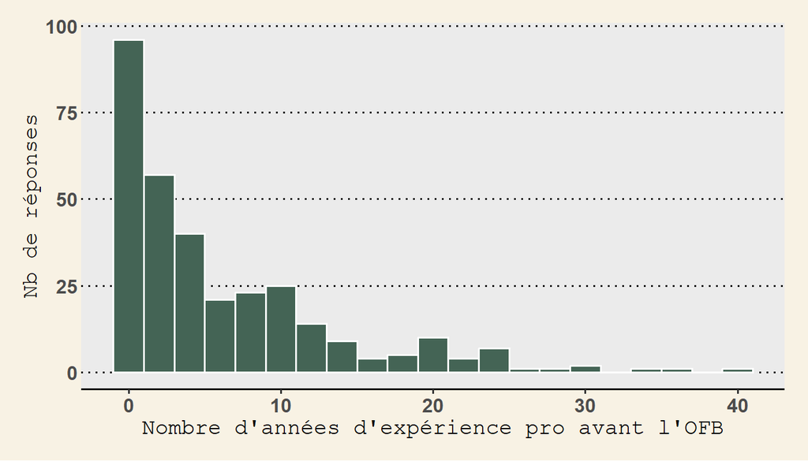

Figure 27: Distribution du nombre d’années d’expérience professionnelle avant l’OFB.

Les deux tiers des précaires sont des femmes, en concordance, hélas, avec les données du RSU de l’OFB.

L’âge des répondant.es s’échelonne entre 20 et 65 ans. Il est en moyenne de 34 ans, ce qui, avec les données d’expérience professionnelle antérieure, contredit le discours mettant en avant des *success stories* de jeunes professionnels à qui l’OFB mettrait le pied à l’étrier. Ce narratif visant à minorer l’impact de la précarité contraste du tableau d’ensemble qui est, hélas, bien moins *glamour*.

> *Comment imaginez-vous les suites à l’issue de votre contrat (plusieurs réponses possibles) ?*

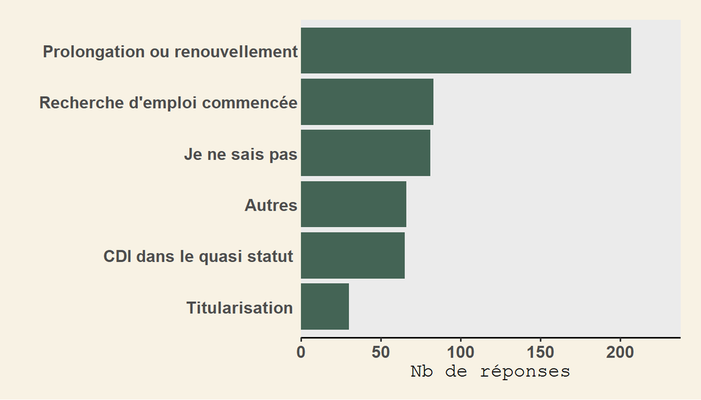

Figure 28: Répartition des réponses selon les perspectives envisagées après le contrat actuel.

La grande majorité des répondant.es aspire à poursuivre l’OFB à l’issue du contrat en cours, ce qui confirme l’attachement aux missions, aux équipes et à l’établissement. En effet, sur les 337 réponses à cette question, 303 (90%) sont “CDI dans le quasi statut”, “Prolongation ou renouvellement” ou “Titularisation”.

# 9 Expression libre …

> *Un mot sur vos aspirations, contrariétés ou autres ressentis ? Sur vos attentes envers les organisations syndicales en général et envers la CGT Environnement en particulier ? Un retour à partager sur votre vécu ?*

En synthèse, les réponses expriment un sentiment d’injustice généralisé : précarité « durable », rémunérations insuffisantes, reconnaissance limitée et perspectives bloquées. Beaucoup d’agents expriment pourtant une forte motivation à s’investir durablement à l’OFB, mais alertent clairement sur le risque de désengagement, de *turnover* contraint (départ forcé de l’OFB la mort dans l’âme) et de perte de compétences dommageables à l’OFB, si ces situations persistent.

Ces réponses peuvent être regroupées en cinq thématiques qui sont, par occurrences décroissantes :

-**Une injustice salariale** (rémunérations inférieures à celles des titulaires et bloquées sur plusieurs années, absence de primes et grilles déconnectées du coût de la vie)

- « *J’ai le sentiment d’être un agent de seconde zone alors que je fais exactement le même travail que mes collègues fonctionnaires. »
- « *Quasiment pas d’augmentation de salaire en 3,5 ans alors que le coût de la vie augmente. »
- « *Pour le même travail, le même salaire que les titulaires. Autrement, on travaille aussi au rabais comme notre rémunération. »

-**Une insécurité permanente** (Les verbatim décrivent une insécurité permanente, y compris sur des fonctions qui sont en réalité pérennes. Le manque de visibilité sur les renouvellements rend difficile toute projection personnelle et professionnelle.)

- « *On a l’impression d’être de la viande dans une boucherie.* »
- « *Je ne comprends pas pourquoi des postes indispensables sont proposés en CDD et non en CDI.* »
- « *Personne n’est capable de me dire si je serai encore en poste dans quelques mois.* »

-**Un accès difficile à la titularisation** (De nombreux agents expriment une attente forte de CDIsation plus rapide, souvent après 3 ans, et dénoncent la longueur excessive des parcours, l’opacité des règles, le faible nombre de postes ouverts aux concours et l’obligation de quitter son poste pour devenir fonctionnaire.)

- « *Sentiment de toujours devoir faire ses preuves et de courir après l’espoir d’être un jour CDIsé.* »
- « *Une “période d’essai” de 6 ans, c’est extrêmement long.* »
- « *Je préfère passer un concours pour avoir un vrai statut, mais les concours ne correspondent pas à mon métier.* »

-**La non-reconnaissance des compétences, diplômes et expériences antérieures** (Les agents dénoncent la faible valorisation des parcours professionnels, notamment les expériences dans le privé, à l’international ou en auto-entrepreneuriat, des diplômes pourtant élevés (doctorat), d’expertise acquises sur le terrain ou en région.)

- « *J’utilise toutes les compétences de mes 10 ans d’expérience, mais je suis payée comme une débutante.* »
- « *Mon doctorat n’est pas valorisé d’une manière ou d’une autre.* »
- « *Mes compétences acquises à l’étranger ont motivé mon recrutement, mais ne sont pas reconnues dans mon salaire.* »

-**Défaillances RH, manque de clarté et stress administratif** (Les verbatims font état de dysfonctionnements RH récurrents : erreurs de paie, documents de fin de contrat absents, informations contradictoires, absence de dialogue et règles appliquées au cas par cas.)

- « *Les règles changent sans cesse et ne sont jamais confirmées officiellement.* »
- « *J’ai attendu des mois sans salaire à cause d’une erreur RH.* »
- « *La RH, c’est à prendre ou à laisser, sans négociation possible.* »

# 10 Conclusions

## 10.1 Principaux enseignements

**Les hypothèses qui ont motivé cette enquête se trouvent largement confirmées**. A l’OFB, de nombreuses missions qui devraient être dévolues à des personnels permanents sont aujourd’hui confiées à des agents précaires. L’incertitude profesionnelle et l’insuffisance de la rémunération impactent fortement la qualité de vie de ces collègues, tant au plan professionnel que personnel.

Au-delà de ces confirmations, le succès de participation, avec un taux de réponse de 62%, révèle une **aspiration des collègues à s’exprimer … et à être entendus**.

Le tableau des impacts de la précarité professionnelle est bien noir, avec des effets très concrets sur les conditions de logement, les trajets domicile - travail, le pouvoir d’achat ou la vie familiale. L’**insuffisance des rémunérations** est fréquemment déplorée. *Plus de la moitié des répondant.es déclare que cette précarité a un impact sur leur santé*. L’incertitude du lendemain empêche de se projeter. Pas étonnant, dans ces conditions, que [la natalité s’effondre en France](https://www.insee.fr/fr/statistiques/8719824#).

L’enquête apporte en outre des pistes sur lesquelles l’OFB gagnerait à progresser, avec en premier lieu une **urgence sur la fonction RH**. Malgré leur implication, nos collègues en charge des RH ne disposent ni des outils, ni du temps nécessaires pour la gestion des statuts précaires. Une augmentation des moyens pour cette fonction essentielle est indispensable.

Ces dysfonctionnements, massivement rapportés, ont pour effet d’accroître la pression à laquelle les personnels précaires sont soumis. Les règles déterminant la **rémunération**, en particulier la **reprise d’ancienneté**, doivent être revues et largement améliorées. **Il est urgent que la DG ouvre les discussions sur ce sujet.**

La date de prise de poste est fréquemment décalée, voire l’embauche annulée au dernier moment. **Plus du quart des répondant.es déclarent avoir dû embaucher sans même avoir en main leur contrat de travail**.

Malgré les griefs énoncés ci-dessous, la grande majorité des sondé.es se voit poursuivre sa carrière à l’OFB. De nombreux *verbatim* expriment les bons côtés du travail dans l’établissement - missions stimulantes et motivantes, soutien de la part des collègues, sens du travail. On observe donc un **tiraillement entre l’attachement aux missions et les difficultés découlant de la précarité**.

## 10.2 Précarité, qualité de vie au travail et risques psycho-sociaux

L’OFB s’est engagé, peu après sa création, dans l’élaboration d’un plan de prévention des risques psycho-sociaux. C’est mieux que rien, mais ce plan est loin de prendre le mal à la racine. Les [facteurs de RPS](https://www.inrs.fr/risques/psychosociaux/facteurs-risques.html) sont connus et, parmi eux, on trouve l’*insécurité de la situation professionnelle*. Les personnels précaires sont également nombreux à déplorer un *manque d’autonomie* avec un moindre accès à la formation et une moindre participation aux décisions et des *rapports sociaux dégradés* en termes de perspectives et de reconnaissance.

[figure not shown]

**Pour améliorer la qualité de vie au travail et limiter les RPS, luttons contre la précarisation des emplois.**